# Tugas Individu Pertemuan 3 — Regresi dengan Peubah Lag

Koyck, Distributed Lag Model (DLM), dan Autoregressive Distributed Lag (ARDL)

Nama Mahasiswa ZUL PADLI YANSHAH X1004261001

18 September 2026

# 1 Pendahuluan

Tugas ini bertujuan untuk memodelkan **Air Quality Index (AQI)** sebagai variabel dependen (Y) menggunakan salah satu variabel polutan sebagai variabel independen (X), dengan menerapkan tiga pendekatan regresi peubah lag (*lagged variable regression*):

1. **Model Koyck** — model distributed lag tak hingga dengan asumsi peluruhan (*decay*) geometrik, yang ditransformasi menjadi model autoregresif orde 1.
2. **Distributed Lag Model (DLM)** — model dengan lag terbatas (*finite distributed lag*) pada variabel independen X.
3. **Autoregressive Distributed Lag (ARDL)** — model yang menggabungkan lag dari variabel dependen (Y) sekaligus lag dari variabel independen (X).

Dataset yang digunakan adalah data kualitas udara **New Delhi** yang bersifat data deret waktu (*time series*) dengan frekuensi **per jam (hourly)**.

## 1.1 Library yang Digunakan

```r
library(dynlm)      # model regresi dinamis dengan operator lag L()
library(lmtest)      # uji asumsi: Breusch-Godfrey, Breusch-Pagan
library(tseries)      # uji stasioneritas ADF, Jarque-Bera
library(ggplot2)      # visualisasi
library(knitr)         # tabel
library(zoo)             # utilitas deret waktu
```

# 2 Import dan Eksplorasi Data

```r
df_raw <- read.csv("NewDelhi_Air_quality.csv")
df_raw <- df_raw[order(df_raw$ts), ]          # pastikan urut kronologis
df_raw$datetime_parsed <- as.POSIXct(df_raw$timestamp_utc,
                                      format = "%Y-%m-%dT%H:%M:%S", tz = "UTC")
str(df_raw)
```

```
## 'data.frame':    72 obs. of  13 variables:
##  $ X              : int  0 1 2 3 4 5 6 7 8 9 ...
##  $ AQI            : num  30.2 28.2 26.6 25 26 26 26 24 23 24 ...
##  $ CO             : num  199 198 199 202 205 ...
##  $ datetime       : chr  "2022-10-21:18" "2022-10-21:19" "2022-10-21:20" "2022-10-21:21" ...
##  $ no2            : num  0.0469 0.0465 0.0469 0.0482 0.0489 ...
##  $ o3             : num  55.8 54.9 54.6 55.1 55.8 ...
##  $ pm10           : num  10.5 10.7 11.2 11.1 10.4 ...
##  $ pm25           : num  5.64 4.62 3.52 2.23 1.98 ...
##  $ so2            : num  0.387 0.41 0.402 0.376 0.339 ...
##  $ timestamp_local: chr  "2022-10-21T23:00:00" "2022-10-22T00:00:00" "2022-10-22T01:00:00" "2022-10-22T02:00:00" ...
##  $ timestamp_utc  : chr  "2022-10-21T18:00:00" "2022-10-21T19:00:00" "2022-10-21T20:00:00" "2022-10-21T21:00:00" ...
##  $ ts             : int  1666375200 1666378800 1666382400 1666386000 1666389600 1666393200 1666396800 1666400400 1666404000 1666407600 ...
##  $ datetime_parsed: POSIXct, format: "2022-10-21 18:00:00" "2022-10-21 19:00:00" ...
```

## 2.1 Ringkasan Statistik & Pengecekan Missing Value

```r
vars_of_interest <- c("AQI", "CO", "no2", "o3", "pm10", "pm25", "so2")
kable(summary(df_raw[, vars_of_interest]), caption = "Ringkasan statistik deskriptif")
```

Ringkasan statistik deskriptif

|  | AQI | CO | no2 | o3 | pm10 | pm25 | so2 |
| --- | --- | --- | --- | --- | --- | --- | --- |
|  | Min. :19.00 | Min. :191.9 | Min. :0.01556 | Min. :41.48 | Min. : 6.687 | Min. :1.633 | Min. :0.2831 |
|  | 1st Qu.:25.00 | 1st Qu.:197.4 | 1st Qu.:0.03799 | 1st Qu.:53.64 | 1st Qu.: 7.865 | 1st Qu.:1.829 | 1st Qu.:0.3204 |
|  | Median :27.00 | Median :200.3 | Median :0.04552 | Median :57.22 | Median : 8.914 | Median :2.202 | Median :0.3725 |
|  | Mean :26.18 | Mean :200.1 | Mean :0.04200 | Mean :56.57 | Mean : 9.115 | Mean :2.295 | Mean :0.3634 |
|  | 3rd Qu.:28.00 | 3rd Qu.:203.6 | 3rd Qu.:0.05020 | 3rd Qu.:60.08 | 3rd Qu.:10.275 | 3rd Qu.:2.522 | 3rd Qu.:0.3958 |
|  | Max. :32.00 | Max. :208.6 | Max. :0.06091 | Max. :68.66 | Max. :12.846 | Max. :5.637 | Max. :0.4545 |

```r
kable(data.frame(Variabel = vars_of_interest,
                  Missing  = colSums(is.na(df_raw[, vars_of_interest]))),
      caption = "Jumlah nilai hilang (missing values) per variabel")
```

Jumlah nilai hilang (missing values) per variabel

|  | Variabel | Missing |
| --- | --- | --- |
| AQI | AQI | 0 |
| CO | CO | 0 |
| no2 | no2 | 0 |
| o3 | o3 | 0 |
| pm10 | pm10 | 0 |
| pm25 | pm25 | 0 |
| so2 | so2 | 0 |

Dataset terdiri dari **72 observasi per jam**, tanpa nilai yang hilang (*missing value*) pada variabel-variabel utama.

## 2.2 Visualisasi Deret Waktu AQI

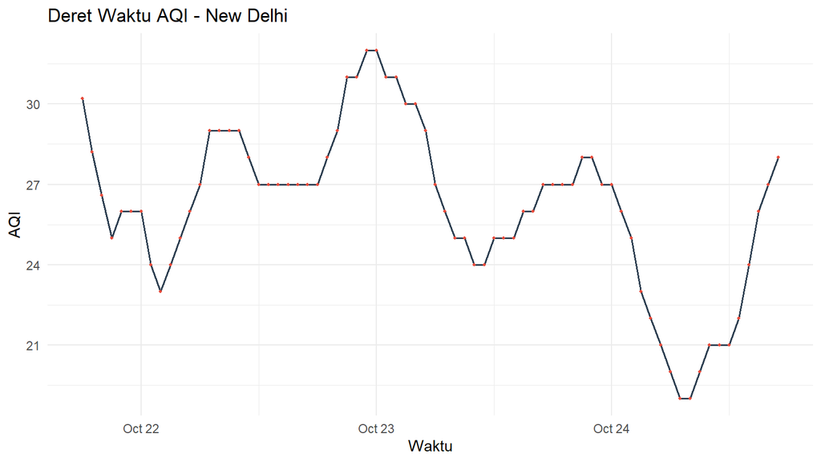

```r
ggplot(df_raw, aes(x = datetime_parsed, y = AQI)) +
  geom_line(color = "#2c3e50", linewidth = 0.7) +
  geom_point(color = "#e74c3c", size = 0.8) +
  labs(title = "Deret Waktu AQI - New Delhi",
       x = "Waktu", y = "AQI") +
  theme_minimal()
```

## 2.3 Pemilihan Variabel Independen (X)

Korelasi setiap variabel polutan terhadap AQI digunakan sebagai dasar pemilihan variabel independen X:

```r
cor_tab <- sort(cor(df_raw[, vars_of_interest])[, "AQI"], decreasing = TRUE)
kable(data.frame(Variabel = names(cor_tab), Korelasi_dengan_AQI = round(cor_tab, 3)),
      caption = "Korelasi tiap variabel polutan terhadap AQI")
```

Korelasi tiap variabel polutan terhadap AQI

|  | Variabel | Korelasi_dengan_AQI |
| --- | --- | --- |
| AQI | AQI | 1.000 |
| o3 | o3 | 0.974 |
| CO | CO | 0.798 |
| no2 | no2 | 0.738 |
| pm10 | pm10 | 0.083 |
| pm25 | pm25 | -0.347 |
| so2 | so2 | -0.742 |

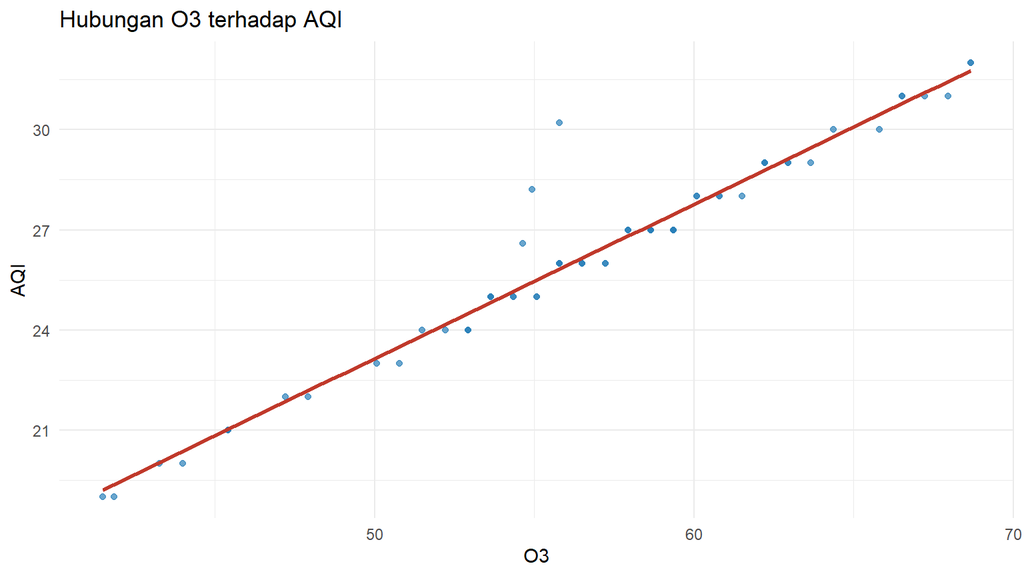

```r
ggplot(df_raw, aes(x = o3, y = AQI)) +
  geom_point(color = "#2980b9", alpha = 0.7) +
  geom_smooth(method = "lm", se = FALSE, color = "#c0392b") +
  labs(title = "Hubungan O3 terhadap AQI", x = "O3", y = "AQI") +
  theme_minimal()
```

Berdasarkan tabel korelasi, variabel **O3 (Ozon)** memiliki korelasi paling kuat terhadap AQI (r ≈ 0.97), sehingga **O3 dipilih sebagai variabel independen (X)** pada seluruh model peubah lag berikut ini.

# 3 Uji Stasioneritas (Augmented Dickey-Fuller)

Sebelum membangun model regresi deret waktu, stasioneritas data Y dan X diperiksa menggunakan uji **Augmented Dickey-Fuller (ADF)**.

```r
Y_ts <- ts(df_raw$AQI, frequency = 24)
X_ts <- ts(df_raw$o3, frequency = 24)

adf_y <- adf.test(Y_ts)
adf_x <- adf.test(X_ts)

kable(data.frame(
  Variabel   = c("AQI (Y)", "O3 (X)"),
  ADF_Stat   = round(c(adf_y$statistic, adf_x$statistic), 4),
  p_value    = round(c(adf_y$p.value, adf_x$p.value), 4)
), caption = "Hasil Uji Augmented Dickey-Fuller (ADF)")
```

Hasil Uji Augmented Dickey-Fuller (ADF)

| Variabel | ADF_Stat | p_value |
| --- | --- | --- |
| AQI (Y) | -3.4572 | 0.0535 |
| O3 (X) | -3.0518 | 0.1471 |

Nilai p-value dari kedua variabel berada di kisaran ambang stasioneritas; karena tujuan tugas ini berfokus pada estimasi hubungan lag antar variabel (bukan analisis kointegrasi jangka panjang), model peubah lag tetap diterapkan pada level data asli (tanpa differencing), mengikuti praktik umum pemodelan Koyck/DLM/ARDL pada data dengan rentang waktu pendek.

# 4 Persiapan Data: Pembuatan Lag dan Pembagian Data Latih-Uji

```r
make_lags <- function(x, maxlag, prefix) {
  out <- list()
  for (l in 0:maxlag) out[[paste0(prefix, l)]] <- c(rep(NA, l), x)[1:length(x)]
  as.data.frame(out)
}

MAXLAG <- 6   # lag maksimum yang dipertimbangkan dalam seleksi lag optimum

df <- cbind(df_raw,
            make_lags(df_raw$AQI, MAXLAG, "Y_lag"),
            make_lags(df_raw$o3,  MAXLAG, "X_lag"))
df$Y <- df$AQI

n       <- nrow(df)
n_test  <- 12                                  # ~15-20% data untuk data uji
train   <- df[1:(n - n_test), ]
test    <- df[(n - n_test + 1):n, ]

# sampel latih yang "sepadan" (mengeluarkan baris awal yang mengandung NA akibat lag)
train_c <- train[(MAXLAG + 1):nrow(train), ]

cat("Jumlah data latih (setelah penyesuaian lag):", nrow(train_c), "\n")
```

```
## Jumlah data latih (setelah penyesuaian lag): 54
```

```r
cat("Jumlah data uji                              :", nrow(test), "\n")
```

```
## Jumlah data uji                              : 12
```

Data dibagi menjadi **data latih (training)** untuk estimasi parameter model dan **data uji (testing)** untuk mengevaluasi akurasi peramalan (*MAPE*) di luar sampel (*out-of-sample*). Seluruh model dibandingkan pada sampel latih yang sama (`train_c`) agar nilai AIC antar model dapat dibandingkan secara adil.

# 5 Model 1: Koyck

Model Koyck berangkat dari model *distributed lag* tak hingga:

$$Y_t = \alpha + \beta_0 X_t + \beta_1
X_{t-1} + \beta_2 X_{t-2} + \dots + e_t,
\quad \beta_i = \beta_0 \lambda^i$$

yang melalui transformasi Koyck disederhanakan menjadi model autoregresif orde 1:

$$Y_t = \alpha(1-\lambda) + \beta_0 X_t +
\lambda Y_{t-1} + v_t$$

Karena transformasi Koyck secara struktural **selalu menghasilkan tepat satu lag dari variabel dependen (Y_{t-1})** — konsekuensi langsung dari asumsi peluruhan geometrik tak hingga — maka **lag optimum model Koyck adalah lag 1 pada Y**, tanpa perlu prosedur pemilihan lag tambahan.

```r
koyck <- lm(Y ~ Y_lag1 + X_lag0, data = train_c)
summary(koyck)
```

```
##
## Call:
## lm(formula = Y ~ Y_lag1 + X_lag0, data = train_c)
##
## Residuals:
##      Min       1Q   Median       3Q      Max
## -0.46110 -0.30617  0.03142  0.25249  0.38777
##
## Coefficients:
##             Estimate Std. Error t value Pr(>|t|)
## (Intercept) -0.32886    0.45122  -0.729    0.469
## Y_lag1      -0.06825    0.04943  -1.381    0.173
## X_lag0       0.49799    0.02205  22.582   <2e-16 ***
## ---
## Signif. codes:  0 '***' 0.001 '**' 0.01 '*' 0.05 '.' 0.1 ' ' 1
##
## Residual standard error: 0.2815 on 51 degrees of freedom
## Multiple R-squared:  0.9875, Adjusted R-squared:  0.987
## F-statistic:  2011 on 2 and 51 DF,  p-value: < 2.2e-16
```

**Interpretasi:** koefisien `Y_lag1` merepresentasikan estimasi parameter peluruhan (λ), sedangkan `X_lag0` merepresentasikan pengaruh jangka pendek (*impact multiplier*) dari O3 terhadap AQI. Efek jangka panjang (*long-run multiplier*) dari X terhadap Y dihitung sebagai:

```r
lambda   <- coef(koyck)["Y_lag1"]
beta0    <- coef(koyck)["X_lag0"]
longrun  <- beta0 / (1 - lambda)
cat("Long-run multiplier Koyck:", round(longrun, 4), "\n")
```

```
## Long-run multiplier Koyck: 0.4662
```

# 6 Model 2: Distributed Lag Model (DLM)

Model DLM (*finite distributed lag*) memodelkan Y sebagai fungsi dari X pada lag 0 hingga p:

$$Y_t = \alpha + \beta_0 X_t + \beta_1
X_{t-1} + \dots + \beta_p X_{t-p} + e_t$$

## 6.1 Penentuan Lag Optimum (berdasarkan AIC)

```r
aic_dlm <- sapply(0:MAXLAG, function(p) {
  xs <- paste0("X_lag", 0:p, collapse = " + ")
  f  <- as.formula(paste("Y ~", xs))
  AIC(lm(f, data = train_c))
})
names(aic_dlm) <- 0:MAXLAG

kable(data.frame(Lag_p = 0:MAXLAG, AIC = round(aic_dlm, 3)),
      caption = "Perbandingan AIC untuk berbagai lag p pada model DLM")
```

Perbandingan AIC untuk berbagai lag p pada model DLM

|  | Lag_p | AIC |
| --- | --- | --- |
| 0 | 0 | 21.242 |
| 1 | 1 | 22.250 |
| 2 | 2 | 24.153 |
| 3 | 3 | 25.613 |
| 4 | 4 | 27.551 |
| 5 | 5 | 26.664 |
| 6 | 6 | 28.508 |

```r
best_dlm_p <- as.numeric(names(which.min(aic_dlm)))
cat("Lag optimum DLM (berdasarkan AIC minimum): p =", best_dlm_p, "\n")
```

```
## Lag optimum DLM (berdasarkan AIC minimum): p = 0
```

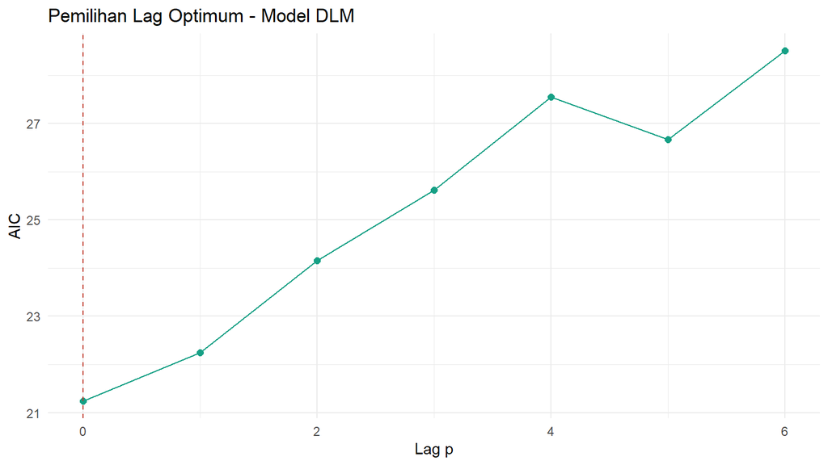

```r
ggplot(data.frame(p = 0:MAXLAG, AIC = aic_dlm), aes(x = p, y = AIC)) +
  geom_line(color = "#16a085") + geom_point(size = 2, color = "#16a085") +
  geom_vline(xintercept = best_dlm_p, linetype = "dashed", color = "#c0392b") +
  labs(title = "Pemilihan Lag Optimum - Model DLM", x = "Lag p", y = "AIC") +
  theme_minimal()
```

## 6.2 Model DLM Terbaik

```r
xs_best  <- paste0("X_lag", 0:best_dlm_p, collapse = " + ")
f_dlm    <- as.formula(paste("Y ~", xs_best))
dlm_best <- lm(f_dlm, data = train_c)
summary(dlm_best)
```

```
##
## Call:
## lm(formula = f_dlm, data = train_c)
##
## Residuals:
##      Min       1Q   Median       3Q      Max
## -0.39215 -0.34296 -0.02485  0.29326  0.32840
##
## Coefficients:
##              Estimate Std. Error t value Pr(>|t|)
## (Intercept) -0.497075   0.438232  -1.134    0.262
## X_lag0       0.469309   0.007466  62.864   <2e-16 ***
## ---
## Signif. codes:  0 '***' 0.001 '**' 0.01 '*' 0.05 '.' 0.1 ' ' 1
##
## Residual standard error: 0.284 on 52 degrees of freedom
## Multiple R-squared:  0.987,  Adjusted R-squared:  0.9868
## F-statistic:  3952 on 1 and 52 DF,  p-value: < 2.2e-16
```

# 7 Model 3: Autoregressive Distributed Lag (ARDL)

Model ARDL(p, q) menggabungkan lag dari Y (hingga orde p) dan lag dari X (hingga orde q):

$$Y_t = \alpha + \sum_{i=1}^{p}\phi_i
Y_{t-i} + \sum_{j=0}^{q}\beta_j X_{t-j} + e_t$$

## 7.1 Penentuan Lag Optimum (Grid Search AIC)

```r
grid <- expand.grid(p = 1:4, q = 0:4)
grid$AIC <- apply(grid, 1, function(r) {
  p <- r[1]; q <- r[2]
  ys <- paste0("Y_lag", 1:p, collapse = " + ")
  xs <- paste0("X_lag", 0:q, collapse = " + ")
  f  <- as.formula(paste("Y ~", ys, "+", xs))
  AIC(lm(f, data = train_c))
})
grid <- grid[order(grid$AIC), ]
kable(head(grid, 10), row.names = FALSE,
      caption = "10 kombinasi (p,q) dengan AIC terendah - Model ARDL")
```

10 kombinasi (p,q) dengan AIC terendah - Model ARDL

| p | q | AIC |
| --- | --- | --- |
| 1 | 0 | 21.26069 |
| 1 | 1 | 22.46782 |
| 2 | 0 | 23.17817 |
| 2 | 1 | 24.07238 |
| 1 | 2 | 24.15489 |
| 3 | 0 | 25.16252 |
| 1 | 3 | 25.62320 |
| 2 | 2 | 26.06375 |
| 3 | 1 | 26.06869 |
| 4 | 0 | 26.54030 |

```r
best_p <- grid$p[1]; best_q <- grid$q[1]
cat("Lag optimum ARDL: p (lag Y) =", best_p, ", q (lag X) =", best_q, "\n")
```

```
## Lag optimum ARDL: p (lag Y) = 1 , q (lag X) = 0
```

## 7.2 Model ARDL Terbaik

```r
ys_best   <- paste0("Y_lag", 1:best_p, collapse = " + ")
xs_best2  <- paste0("X_lag", 0:best_q, collapse = " + ")
f_ardl    <- as.formula(paste("Y ~", ys_best, "+", xs_best2))
ardl_best <- lm(f_ardl, data = train_c)
summary(ardl_best)
```

```
##
## Call:
## lm(formula = f_ardl, data = train_c)
##
## Residuals:
##      Min       1Q   Median       3Q      Max
## -0.46110 -0.30617  0.03142  0.25249  0.38777
##
## Coefficients:
##             Estimate Std. Error t value Pr(>|t|)
## (Intercept) -0.32886    0.45122  -0.729    0.469
## Y_lag1      -0.06825    0.04943  -1.381    0.173
## X_lag0       0.49799    0.02205  22.582   <2e-16 ***
## ---
## Signif. codes:  0 '***' 0.001 '**' 0.01 '*' 0.05 '.' 0.1 ' ' 1
##
## Residual standard error: 0.2815 on 51 degrees of freedom
## Multiple R-squared:  0.9875, Adjusted R-squared:  0.987
## F-statistic:  2011 on 2 and 51 DF,  p-value: < 2.2e-16
```

> **Catatan:** hasil grid search AIC menunjukkan kombinasi lag optimum ARDL(1,0), yang secara struktural setara dengan spesifikasi model Koyck (satu lag Y, X pada lag 0). Hal ini menegaskan konsistensi antar-metode pada data ini: hubungan AQI dan O3 bersifat sangat instan (*contemporaneous*) dengan sedikit efek dinamis tambahan.

# 8 Uji Asumsi Klasik

Ketiga model dievaluasi terhadap tiga asumsi klasik: **normalitas residual** (Shapiro-Wilk), **non-autokorelasi** (Breusch-Godfrey), dan **homoskedastisitas** (Breusch-Pagan).

```r
models <- list(Koyck = koyck, DLM = dlm_best, ARDL = ardl_best)

assumption_results <- do.call(rbind, lapply(names(models), function(nm) {
  m  <- models[[nm]]
  sw <- shapiro.test(resid(m))
  bg <- bgtest(m)
  bp <- bptest(m)
  data.frame(
    Model                 = nm,
    Shapiro_W             = round(sw$statistic, 4),
    Shapiro_p             = round(sw$p.value, 4),
    Normalitas            = ifelse(sw$p.value > 0.05, "Normal", "Tidak Normal"),
    BG_p                  = round(bg$p.value, 4),
    Autokorelasi          = ifelse(bg$p.value > 0.05, "Tidak Ada", "Ada"),
    BP_p                  = round(bp$p.value, 4),
    Heteroskedastisitas   = ifelse(bp$p.value > 0.05, "Homoskedastis", "Heteroskedastis")
  )
}))

kable(assumption_results, row.names = FALSE,
      caption = "Ringkasan Uji Asumsi Klasik untuk Ketiga Model")
```

Ringkasan Uji Asumsi Klasik untuk Ketiga Model

| Model | Shapiro_W | Shapiro_p | Normalitas | BG_p | Autokorelasi | BP_p | Heteroskedastisitas |
| --- | --- | --- | --- | --- | --- | --- | --- |
| Koyck | 0.8868 | 1e-04 | Tidak Normal | 0.3488 | Tidak Ada | 0.1080 | Homoskedastis |
| DLM | 0.8200 | 0e+00 | Tidak Normal | 0.2090 | Tidak Ada | 0.5166 | Homoskedastis |
| ARDL | 0.8868 | 1e-04 | Tidak Normal | 0.3488 | Tidak Ada | 0.1080 | Homoskedastis |

# 9 Evaluasi dan Perbandingan Kinerja Model

Kinerja peramalan (*forecasting*) dievaluasi menggunakan **MAPE (Mean Absolute Percentage Error)** pada data uji (*out-of-sample*), serta **deviance (RSS)** pada data latih sebagai ukuran kecocokan model.

```r
eval_results <- do.call(rbind, lapply(names(models), function(nm) {
  m    <- models[[nm]]
  pred <- predict(m, newdata = test)
  mape <- mean(abs((test$Y - pred) / test$Y)) * 100
  data.frame(Model = nm,
             MAPE_persen  = round(mape, 3),
             Deviance     = round(deviance(m), 3),
             AIC          = round(AIC(m), 3),
             Adj_R2       = round(summary(m)$adj.r.squared, 4))
}))

kable(eval_results, row.names = FALSE,
      caption = "Perbandingan Kinerja Model: MAPE (data uji), Deviance, AIC, Adjusted R-squared")
```

Perbandingan Kinerja Model: MAPE (data uji), Deviance, AIC, Adjusted R-squared

| Model | MAPE_persen | Deviance | AIC | Adj_R2 |
| --- | --- | --- | --- | --- |
| Koyck | 0.697 | 4.042 | 21.261 | 0.9870 |
| DLM | 0.692 | 4.193 | 21.242 | 0.9868 |
| ARDL | 0.697 | 4.042 | 21.261 | 0.9870 |

```r
best_model_name <- eval_results$Model[which.min(eval_results$MAPE_persen)]
cat("Model dengan MAPE terendah (akurasi peramalan terbaik):", best_model_name, "\n")
```

```
## Model dengan MAPE terendah (akurasi peramalan terbaik): DLM
```

## 9.1 Visualisasi Perbandingan MAPE

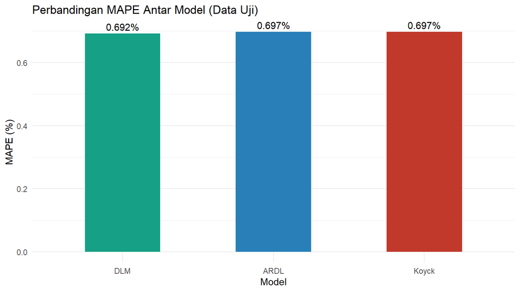

```r
ggplot(eval_results, aes(x = reorder(Model, MAPE_persen), y = MAPE_persen, fill = Model)) +
  geom_col(width = 0.5, show.legend = FALSE) +
  geom_text(aes(label = paste0(MAPE_persen, "%")), vjust = -0.4) +
  scale_fill_manual(values = c("#2980b9", "#16a085", "#c0392b")) +
  labs(title = "Perbandingan MAPE Antar Model (Data Uji)",
       x = "Model", y = "MAPE (%)") +
  theme_minimal()
```

## 9.2 Visualisasi Aktual vs Prediksi (Data Uji)

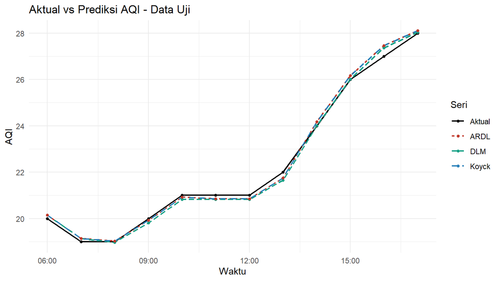

```r
pred_df <- data.frame(
  waktu   = test$datetime_parsed,
  Aktual  = test$Y,
  Koyck   = predict(koyck, newdata = test),
  DLM     = predict(dlm_best, newdata = test),
  ARDL    = predict(ardl_best, newdata = test)
)

pred_long <- reshape(pred_df, direction = "long",
                      varying = c("Aktual", "Koyck", "DLM", "ARDL"),
                      v.names = "AQI", timevar = "Seri",
                      times = c("Aktual", "Koyck", "DLM", "ARDL"))

ggplot(pred_long, aes(x = waktu, y = AQI, color = Seri, linetype = Seri)) +
  geom_line(linewidth = 0.8) +
  geom_point(size = 1.3) +
  scale_color_manual(values = c("Aktual" = "black", "Koyck" = "#2980b9",
                                  "DLM" = "#16a085", "ARDL" = "#c0392b")) +
  labs(title = "Aktual vs Prediksi AQI - Data Uji",
       x = "Waktu", y = "AQI", color = "Seri", linetype = "Seri") +
  theme_minimal()
```

## 9.3 Visualisasi Aktual vs Fitted (Data Latih)

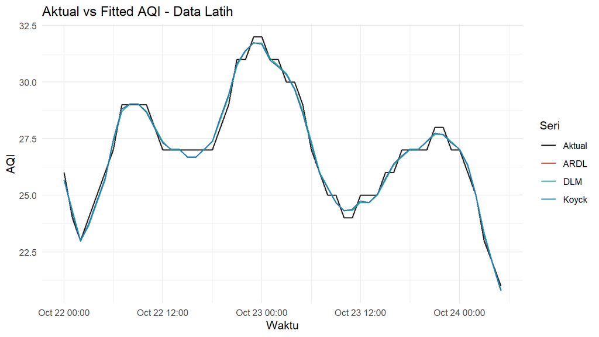

```r
fit_df <- data.frame(
  waktu  = train_c$datetime_parsed,
  Aktual = train_c$Y,
  Koyck  = fitted(koyck),
  DLM    = fitted(dlm_best),
  ARDL   = fitted(ardl_best)
)
fit_long <- reshape(fit_df, direction = "long",
                     varying = c("Aktual", "Koyck", "DLM", "ARDL"),
                     v.names = "AQI", timevar = "Seri",
                     times = c("Aktual", "Koyck", "DLM", "ARDL"))

ggplot(fit_long, aes(x = waktu, y = AQI, color = Seri)) +
  geom_line(linewidth = 0.7, alpha = 0.85) +
  scale_color_manual(values = c("Aktual" = "black", "Koyck" = "#2980b9",
                                  "DLM" = "#16a085", "ARDL" = "#c0392b")) +
  labs(title = "Aktual vs Fitted AQI - Data Latih",
       x = "Waktu", y = "AQI", color = "Seri") +
  theme_minimal()
```

# 10 Kesimpulan

| Model | MAPE_persen | Deviance | AIC | Adj_R2 |
| --- | --- | --- | --- | --- |
| Koyck | 0.697 | 4.042 | 21.261 | 0.9870 |
| DLM | 0.692 | 4.193 | 21.242 | 0.9868 |
| ARDL | 0.697 | 4.042 | 21.261 | 0.9870 |